# Lista 10 - Mapeamento de QTLs IV

Cristiane Taniguti, Fernando Correr, Fernando Espolador, Jhonathan dos Santos

June 2, 2017

1. Considere o conjunto de dados de Mimulus, já usado em aulas anteriores. Usando o mapa que você construiu anteriormente com o OneMap, faça mapeamento por intervalo e por intervalo composto para localizar QTL’s para uma das características presentes no conjunto de dados (escolha a que julgar mais interessante).
- Determine o limiar para rejeitar H0 e apresente os resultados de forma gráfica e em tabelas de forma semelhante aos artigos publicados na área.
- Use o software R/qtl, verificando no tutorial do OneMap como exportar o mapa construído para o formato do R/qtl. Use o Fórum para resolver suas dúvidas.
- O exercício pode ser feito em grupo, pela mesma equipe que fez o mapa genético.
- Apresente os resultados em um arquivo html
- Faça um vídeo no Youtube apresentando e interpretando os resultados. Coloque o link do vídeo no Fórum.

A construção do mapa genético do Mimulus foi realizada em uma atividade anterior da mesma disciplina de Biometria de Marcadores Genéticos da Esalq. Mais informações podem ser encontradas acessando o [link](http://cristianetaniguti.github.io/2017/05/19/Contru%C3%A7%C3%A3o-de-Mapa-Gen%C3%A9tico-no-Onemap.html).

O primeiro passo desta atividade é exportar o mapa através da função *write_map* do pacote *onemap*, de forma que possa ser um dos arquivos de entrada do *R/qtl*.

```r
#Carregando os pacotes onemap e qtl:
library(onemap)
library(qtl)
library(knitr)

# Carregando informações do mapa construído
load("mapa_datas.RData")

# Exportando informações para arquivo de entrada do R/qtl
write_map(mapa, "mimulus.map")
```

## Mapeamento por intervalo

No mapeamento de QTLs através do R/qtl é necessário, além do mapa genético, o arquivo bruto do formato MAPMAKER. Isso é necessário para que ele possa reconhecer o tipo de cruzamento, os marcadores e fenótipos envolvidos no experimento. Será verificado, como no exercício de mapeamento genético, que se trata de uma população $F_2$ onde foram genotipados 418 marcadores em 287 indivíduos e foram avaliados 16 fenótipos que consistem em características florais, reprodutivas e vegetativas (melhor descritas em Fishman et al. 2002).

```r
#Realizando a leitura dos dados do experimento de QTL:
mimulus.qtl <- read.cross(format = "mm", file = "m_feb06.raw",
                        mapfile = "mimulus.map")
```

```
##  --Read the following data:
##  Type of cross:          f2
##  Number of individuals:  287
##  Number of markers:      418
##  Number of phenotypes:   16
##  --Cross type: f2
```

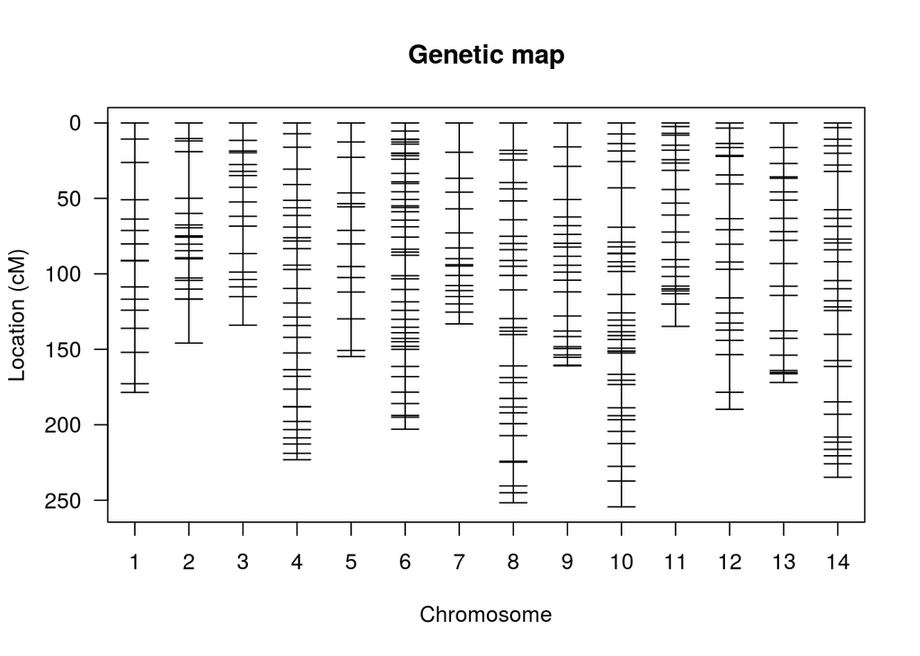

```r
#Observar o mapa genético:
plot.map(mimulus.qtl)
```

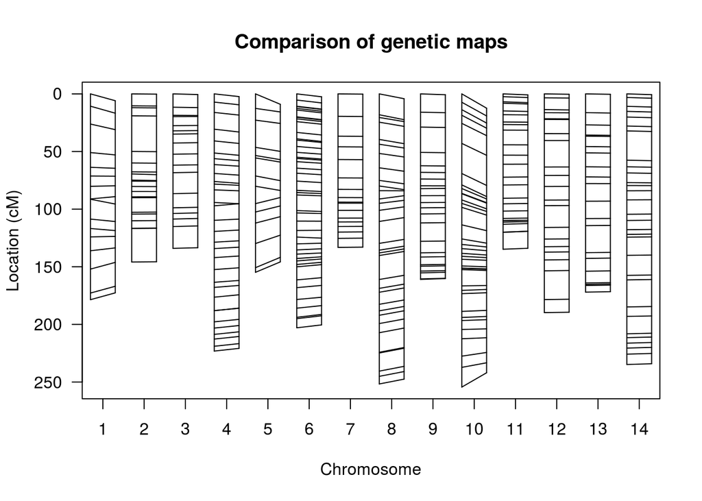

```r
#Reestimar o mapa - checagem do mapa:
newmap <- est.map(mimulus.qtl, tol = 1e-6, map.function = "kosambi")

#Nota-se que os mapas são praticamente idênticos:
plot.map(mimulus.qtl, newmap)
```

A função *est.map* faz a reestimativa do mapa genético de acordo com o algoritmo Lander-Green. Comparando o mapa construído (à esquerda) com o mapa reestimado, nota-se que são muito similares, sendo notada uma diminuição mais aparente dos grupos de ligação 1, 5, 8 e 10. Nos grupos 1, 4, 5 e 8 é possível observar ou a separação entre dois marcadores muito próximos ou a aproximação de dois marcadores.

Agora, será realizado o mapeamento por intervalo com o algoritmo EM e a regressão Haley-Knott. Inicialmente é essencial calcular as probabilidades condicionais de cada genótipo através da função *calc.genoprob*. Serão considerados “passos” de 1cM e será assumida uma taxa de erro de genotipagem de 1%. Em seguida, é feito o escaneamento do genoma para buscar QTL. Aqui consideraremos apenas um dos fenótipos avaliados, o número de pólens não viáveis (nv).

Os objetos *out.em* e *out.hk* indicam os métodos EM e Haley-Knott utilizados para a busca de QTLs para essa característica.

```r
#Realizando o mapeamento por intervalo - Com os algoritmo EM e regressão Haley-Knott:
mimulus.qtl.prob <- calc.genoprob(mimulus.qtl, step=1, error.prob=0.01)

##EM:
out.em <- scanone(mimulus.qtl.prob, method = "em", pheno.col = 5)

##Haley-Knott:
out.hk <- scanone(mimulus.qtl.prob, method="hk", pheno.col = 5)

# Maiores valores de LOD para os dois casos
#EM:
kable(summary(out.em))
```

|  | chr | pos | lod |
| --- | --- | --- | --- |
| CA389C | 1 | 80.17989 | 2.0840674 |
| c2.loc27 | 2 | 27.00000 | 2.2556121 |
| AG19 | 3 | 134.01698 | 2.8268231 |
| c4.loc147 | 4 | 147.00000 | 1.3534722 |
| BB186 | 5 | 0.00000 | 2.3170831 |
| c6.loc36 | 6 | 36.00000 | 1.6093390 |
| c7.loc129 | 7 | 129.00000 | 1.4340664 |
| c8.loc134 | 8 | 134.00000 | 0.9824759 |
| MgSTS536 | 9 | 28.78428 | 2.0666186 |
| c10.loc211 | 10 | 211.00000 | 1.6002020 |
| MgSTS561 | 11 | 113.14222 | 0.9843905 |
| CB216 | 12 | 13.60661 | 0.6481818 |
| c13.loc149 | 13 | 149.00000 | 12.8935216 |
| c14.loc214 | 14 | 214.00000 | 1.5905898 |

```r
#Haley-Knott
kable(summary(out.hk))
```

|  | chr | pos | lod |
| --- | --- | --- | --- |
| CA389C | 1 | 80.17989 | 2.0480840 |
| c2.loc30 | 2 | 30.00000 | 2.4707325 |
| AG19 | 3 | 134.01698 | 2.8463443 |
| c4.loc147 | 4 | 147.00000 | 1.3454197 |
| c5.loc5 | 5 | 5.00000 | 2.1486857 |
| c6.loc36 | 6 | 36.00000 | 1.6529353 |
| c7.loc130 | 7 | 130.00000 | 1.4944047 |
| c8.loc134 | 8 | 134.00000 | 0.9979106 |
| MgSTS536 | 9 | 28.78428 | 2.1166201 |
| c10.loc210 | 10 | 210.00000 | 1.6173384 |
| c11.loc112 | 11 | 112.00000 | 1.0283502 |
| CB216 | 12 | 13.60661 | 0.6430561 |
| c13.loc151 | 13 | 151.00000 | 11.6791235 |
| c14.loc214 | 14 | 214.00000 | 1.6113803 |

As duas tabelas apresentam os maiores valores de LOD para cada um dos grupos de ligação. Há uma correspondência entre as posições apontadas pelos dois métodos, se nos intervalos a posição não foi a mesma entre os métodos, é possível verificar que são bem aproximadas.

Para detectar que o LOD é significativo, ou seja, maior do que um determinado limiar, será utilizada a estratégia de permutações. Utiliza-se a função *scanone* com 5000 permutações com a regressão Haley-Knott considerando o fenótipo que já estávamos utilizando. Nas permutações quebra-se a associação entre genótipo e fenótipo, de modo que obteremos uma distribuição empírica dos dados e definiremos o limiar como aquele que indica o percentil 95%.

```r
# Calculando o limiar de LOD por permutações pelo modelo de hk
operm.hk <- scanone(mimulus.qtl.prob, method="hk", n.perm=5000, pheno.col = 5)
```

```
## Doing permutation in batch mode ...
```

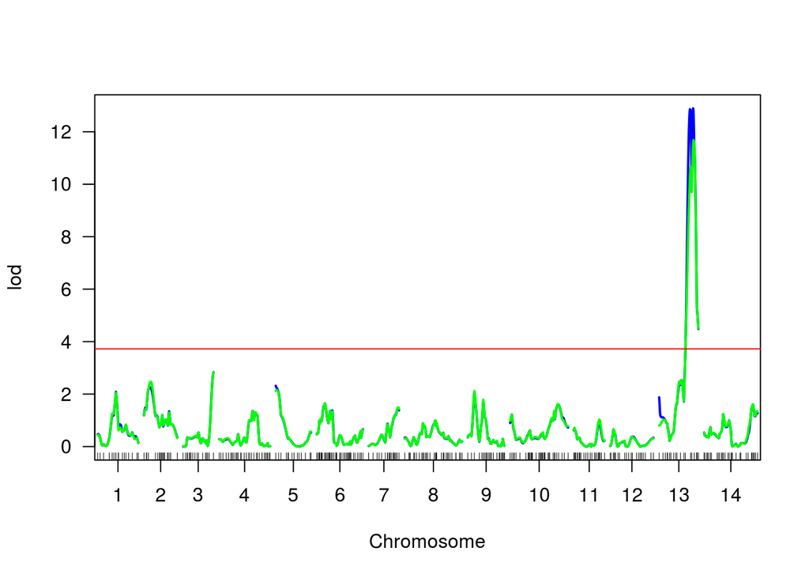

```r
thr <- summary(operm.hk, alpha=0.05)
thr <- as.numeric(thr)

#Fazendo o gráfico do perfil de LOD score
## Linha azul é por EM e verde por hk

plot(out.em, out.hk, col=c("blue", "green"))
#Utilizando o limiar
abline(h = thr, col = "red")
```

```r
# Intervalo de confiança, considerando regra de 1 LOD
intervalo <- lodint(out.em, chr=13, drop=1)
knitr::kable(intervalo)
```

|  | chr | pos | lod |
| --- | --- | --- | --- |
| c13.loc129 | 13 | 129 | 11.56160 |
| c13.loc149 | 13 | 149 | 12.89352 |
| c13.loc153 | 13 | 153 | 11.80792 |

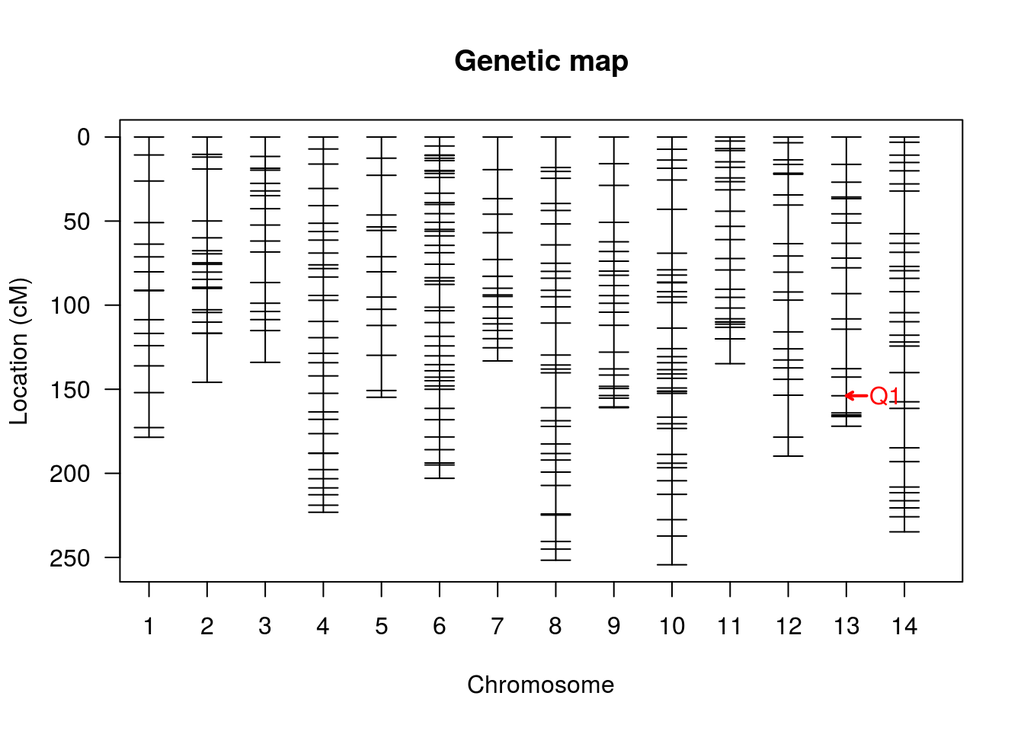

```r
# Localização dos QTLs no mapa
QTLs <- summary(out.em, threshold = thr)
mimulus.sim <- sim.geno(mimulus.qtl.prob)
qtlsim <- makeqtl(mimulus.sim, chr = QTLs$chr, pos = QTLs$pos)
plot(qtlsim)
```

Por meio do gráfico do perfil de LOD score no genoma pelo método com o uso do EM, verifica-se um pico superior ao limiar, localizado no grupo de ligação 13. Com a função `effectplot` é possível obter estimativas da média fenotípica específica de cada genótipo para o marcador vinculado ao QTL. Com tais valores obtemos os efeitos genéticos aditivos e de dominância do QTL significativo:

$a = (\mu_{BB} - \mu_{AA})/2$

$d = \mu_{AB} - (\mu_{AA} + \mu_{BB})/2$

```r
# Localizando marcadores relacionados com os maiores picos
picos <- find.marker(mimulus.qtl.prob, QTLs$chr, QTLs$pos)
picos
```

```
## [1] "MgSTS104"
```

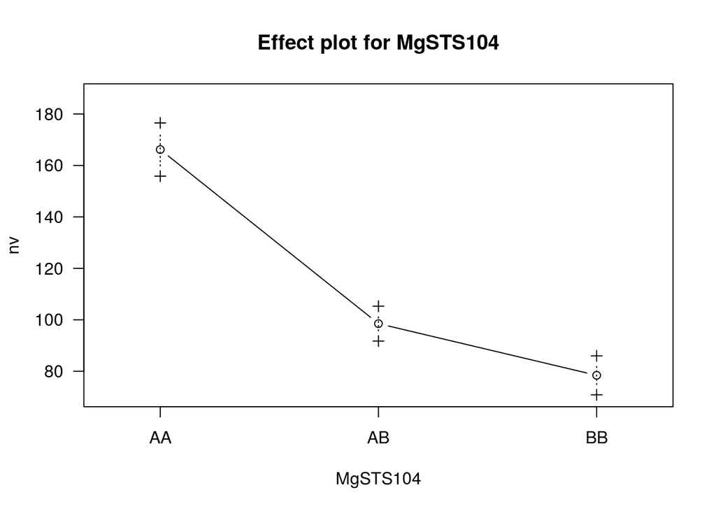

```r
effect_a <- effect_d <- vector()
for (i in 1:length(picos)){
  # gráfico que mostra a diferença entre as médias
  #effectplot(mimulus.qtl.prob, mname1=picos[i])

  # plotando mais detalhes
  #plot.pxg(mimulus.qtl.prob, marker=picos[i])

  # Obtendo médias para cada genótipo
  eff <- effectplot(mimulus.sim, mname1=picos[i], draw=TRUE, pheno.col = 5)

  # Calculando efeitos aditivo e de dominância
  effect_a <- c(effect_a, (eff$Means[3] - eff$Means[1])/2)
  effect_d <- c(effect_d, eff$Means[2] - (eff$Means[1] + eff$Means[3])/2)
}
```

```r
# Tais valores também podem ser obtidos com a função `fitqtl`

model1 <- fitqtl(mimulus.sim, pheno.col = 5,  qtl = qtlsim, get.ests = TRUE)
resumo <- summary(model1)

IM_QTLs <- data.frame("marcador"= rownames(QTLs),"cromossomo"= QTLs$chr,
                      "posição" = QTLs$pos, "LOD" = QTLs$lod,
             "efeito aditivo" = resumo$ests[2,1] ,
             "efeito de dominância"= resumo$ests[3,1],
             "R^2" = resumo$result.full[1,5])

knitr::kable(IM_QTLs)
```

| marcador | cromossomo | posição | LOD | efeito.aditivo | efeito.de.dominância | R.2 |
| --- | --- | --- | --- | --- | --- | --- |
| c13.loc149 | 13 | 149 | 12.89352 | -43.23673 | -24.51985 | 16.35856 |

A próxima etapa é verificar as possíveis alterações neste perfil ao adicionarmos covariáveis no modelo.

# Mapeamento por intervalo composto

No mapeamento por intervalo composto serão utilizados marcadores como covariáveis durante a estimativa do efeito nas posições. É importante ressaltar que essas covariáveis são utilizadas ao longo de todo o genoma e bem como no mesmo grupo de ligação onde está sendo escaneado o QTL. Nesse último caso, deve ser definido um tamanho de janelas para “isolar” a região próxima à posição testada.

A função *cim* realiza a seleção forward para fixar um número de marcadores (especificados pelo argumento n.marcovar), seguido por mapeamento por intervalo, omitindo os marcadores definidos como covariáveis presentes a uma distância fixa (determinada pelo argumento window) do ponto testado.

Para definir o número de covariáveis, foram investigados os resultados de regressão nas marcas e também o número de picos obtidos através do mapeamento por intervalo. Sobre o número de picos na análise anterior foi escolhido abranger apenas o pico considerado significativo localizado no cromossomo 13.

Sobre a regressão nas marcas, definimos um LOD de 3 na tentativa de abranger mais marcadores ao longo do genoma. Esse valor de LOD foi também evidenciado apenas o pico no cromossomo 13.

A decisão tomada foi utilizar apenas um marcador como covariável. Ressalta-se, mais uma vez, que essas investigações foram apenas para definir um número de covariáveis para ser empregado no mapeamento por intervalo composto.

```r
############################################
#Utilizando a regressão nas marcas:
out.mr <- scanone(mimulus.qtl, method="mr", pheno.col = 5)
#Verificando aquelas superior a um LOD de 2.5:
kable(summary(out.mr, threshold=3))
```

|  | chr | pos | lod |
| --- | --- | --- | --- |
| MgSTS104 | 13 | 153.8571 | 10.06273 |

```r
##############      CIM    ##################
out.cim.20 <- cim(mimulus.qtl.prob, n.marcovar=1, window=15, pheno.col = 5)
```

```r
###################### LIMIAR
permic_5 <- cim(mimulus.qtl.prob, n.marcovar = 1, window = 15, pheno.col = 5, n.perm = 5000, method = "hk") # Processamento demorado
```

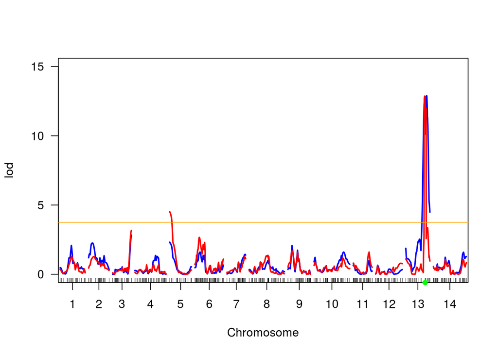

```r
############### Gráfico do perfil de LOD
lim <- summary(permic_5, alpha = 0.05)

plot(out.em,col="blue", ylim = c(0,15));
plot(out.cim.20,  col= "red", add = TRUE);
add.cim.covar(out.cim.20, col="green")
abline(h=lim[1], col = "orange")
```

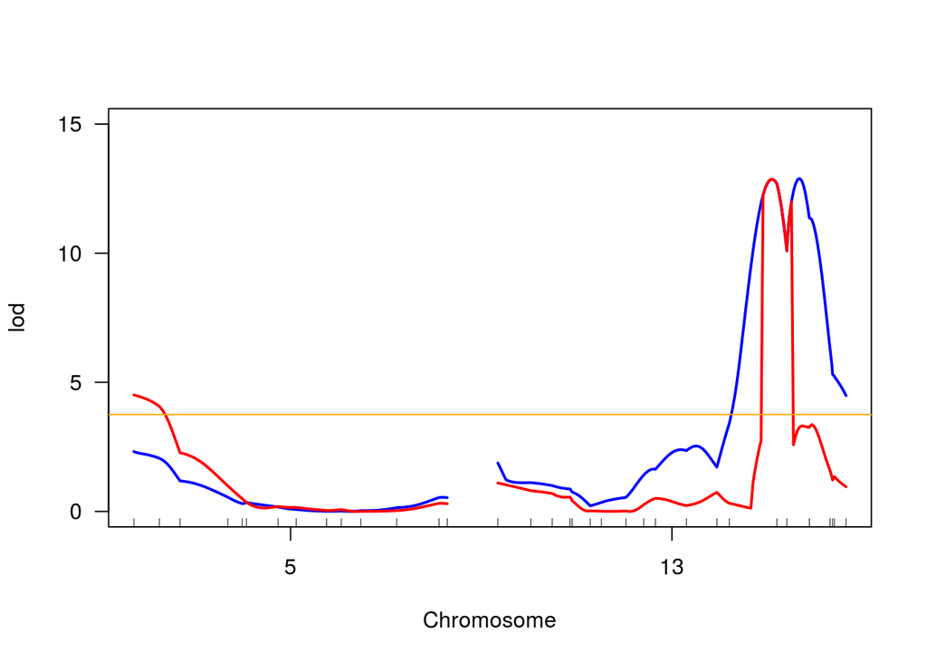

```r
plot(out.em,col="blue", chr = c(5,13), ylim = c(0,15));
plot(out.cim.20,  col= "red", chr = c(5,13), add = TRUE);
add.cim.covar(out.cim.20, col="green")
abline(h=lim[1], col = "orange")
```

```r
# Intervalo de confiança considerando a regra de 1 LOD
intervalo13 <- lodint(out.cim.20, chr=13, drop=1)
intervalo6 <- lodint(out.cim.20, chr=5, drop=1)
intervalo <- rbind(intervalo6, intervalo13)
knitr::kable(intervalo)
```

|  | chr | pos | lod |
| --- | --- | --- | --- |
| BB186 | 5 | 0 | 4.511880 |
| BB186 | 5 | 0 | 4.511880 |
| c5.loc17 | 5 | 17 | 3.497126 |
| c13.loc130 | 13 | 130 | 2.729978 |
| c13.loc135 | 13 | 135 | 12.860446 |
| c13.loc146 | 13 | 146 | 2.580033 |

Para determinar os efeitos dos QTLs encontrados, é necessário considerar os efeitos da covariável utilizada no mapeamento por intervalo composto:

```r
covar <- attr(out.cim.20,"marker.covar.pos")
covar
```

```
##      chr      pos
## CB55  13 137.7798
```

Também consideraremos os QTLs significativos encontrado.

```r
QTL <- summary(out.cim.20, threshold = lim[1])
QTL
```

```
##            chr pos   lod
## BB186        5   0  4.51
## c13.loc135  13 135 12.86
```

Com função `fitqtl` montamos um modelo considerando os efeitos da covariável e do QTL (que no caso coincidem). Dessa forma podemos identificar o efeito do QTL.

```r
qtls <- makeqtl(mimulus.sim, chr = QTL$chr, pos = QTL$pos)

model <- fitqtl(mimulus.sim, pheno.col = 5,  qtl = qtls, get.ests = TRUE)
resumo <- summary(model)

CIM_QTLs <- data.frame("marcador"= rownames(QTL),"cromossomo"= QTL$chr,"posição" =
               QTL$pos, "LOD" = QTL$lod,
             "efeito aditivo" = c(resumo$ests[2,1],resumo$ests[4,1]) ,
             "efeito de dominância"= c(resumo$ests[3,1],resumo$ests[5,1]),
             "R^2" = resumo$result.drop[,4])

knitr::kable(CIM_QTLs)
```

|  | marcador | cromossomo | posição | LOD | efeito.aditivo | efeito.de.dominância | R.2 |
| --- | --- | --- | --- | --- | --- | --- | --- |
| 5@0.0 | BB186 | 5 | 0 | 4.51188 | -26.44937 | 2.834529 | 4.897425 |
| 13@137.8 | c13.loc135 | 13 | 135 | 12.86045 | -46.21984 | -7.214839 | 16.155726 |